# Salary Prediction Ultimatum - Assignment 03

You should complete this Jupyter Notebook with your answers. You may need to write code or add explanatory notes.

dataset link: https://www.kaggle.com/datasets/pavansubhasht/ibm-hr-analytics-attrition-dataset/data

```python
# Step 1: Upload the kaggle.json file manually
from google.colab import files
files.upload()

# Step 2: Create the .kaggle directory
!mkdir -p ~/.kaggle

# Step 3: Move kaggle.json to the .kaggle directory
!cp kaggle.json ~/.kaggle/

# Step 4: Set permissions for the kaggle.json file
!chmod 600 ~/.kaggle/kaggle.json
```

Upload widget is only available when the cell has been executed in the current browser session. Please rerun this cell to enable.

```
Saving kaggle.json to kaggle.json
```

```python
!mkdir -p /DataMining
!kaggle datasets download -d pavansubhasht/ibm-hr-analytics-attrition-dataset -p /DataMining
import zipfile
folder_name = '/DataMining'
zip_path = f"{folder_name}/ibm-hr-analytics-attrition-dataset.zip"
with zipfile.ZipFile(zip_path, 'r') as zip_ref:
    zip_ref.extractall(folder_name)
```

```
Dataset URL: https://www.kaggle.com/datasets/pavansubhasht/ibm-hr-analytics-attrition-dataset
License(s): DbCL-1.0
Downloading ibm-hr-analytics-attrition-dataset.zip to /DataMining
  0% 0.00/50.1k [00:00<?, ?B/s]
100% 50.1k/50.1k [00:00<00:00, 248MB/s]
```

```python
import pandas as pd
df = pd.read_csv(f"{folder_name}/WA_Fn-UseC_-HR-Employee-Attrition.csv")
df.head()
```

|  | Age | Attrition | BusinessTravel | DailyRate | Department | DistanceFromHome | Education | EducationField | EmployeeCount | EmployeeNumber | ... | RelationshipSatisfaction | StandardHours | StockOptionLevel | TotalWorkingYears | TrainingTimesLastYear | WorkLifeBalance | YearsAtCompany | YearsInCurrentRole | YearsSinceLastPromotion | YearsWithCurrManager |
| --- | --- | --- | --- | --- | --- | --- | --- | --- | --- | --- | --- | --- | --- | --- | --- | --- | --- | --- | --- | --- | --- |
| 0 | 41 | Yes | Travel_Rarely | 1102 | Sales | 1 | 2 | Life Sciences | 1 | 1 | ... | 1 | 80 | 0 | 8 | 0 | 1 | 6 | 4 | 0 | 5 |
| 1 | 49 | No | Travel_Frequently | 279 | Research & Development | 8 | 1 | Life Sciences | 1 | 2 | ... | 4 | 80 | 1 | 10 | 3 | 3 | 10 | 7 | 1 | 7 |
| 2 | 37 | Yes | Travel_Rarely | 1373 | Research & Development | 2 | 2 | Other | 1 | 4 | ... | 2 | 80 | 0 | 7 | 3 | 3 | 0 | 0 | 0 | 0 |
| 3 | 33 | No | Travel_Frequently | 1392 | Research & Development | 3 | 4 | Life Sciences | 1 | 5 | ... | 3 | 80 | 0 | 8 | 3 | 3 | 8 | 7 | 3 | 0 |
| 4 | 27 | No | Travel_Rarely | 591 | Research & Development | 2 | 1 | Medical | 1 | 7 | ... | 4 | 80 | 1 | 6 | 3 | 3 | 2 | 2 | 2 | 2 |

5 rows × 35 columns

```python
df.info()
```

```
<class 'pandas.core.frame.DataFrame'>
RangeIndex: 1470 entries, 0 to 1469
Data columns (total 35 columns):
 #   Column                    Non-Null Count  Dtype
---  ------                    --------------  -----
 0   Age                       1470 non-null   int64
 1   Attrition                 1470 non-null   object
 2   BusinessTravel            1470 non-null   object
 3   DailyRate                 1470 non-null   int64
 4   Department                1470 non-null   object
 5   DistanceFromHome          1470 non-null   int64
 6   Education                 1470 non-null   int64
 7   EducationField            1470 non-null   object
 8   EmployeeCount             1470 non-null   int64
 9   EmployeeNumber            1470 non-null   int64
```

[output cut: 27 more lines]

## Background

Mr. Bayes, is a data scientist at a high-tech Silicon Valley company. Due to economic instability, your notoriously impatient manager, Mr. Grumbleworth, has tasked him with building a salary prediction model to ensure no employee is overpaid.

"I don’t want to pay a dollar more than necessary. Justify every decision—or you’re fired!" Mr. Grumbleworth said.

You must help Mr, Bayes analyze the IBM HR Analytics dataset and deliver a Jupyter Notebook with your findings.

```python
df.columns
#df["Department"].unique()
```

```
Index(['Age', 'Attrition', 'BusinessTravel', 'DailyRate', 'Department',
       'DistanceFromHome', 'Education', 'EducationField', 'EmployeeCount',
       'EmployeeNumber', 'EnvironmentSatisfaction', 'Gender', 'HourlyRate',
       'JobInvolvement', 'JobLevel', 'JobRole', 'JobSatisfaction',
       'MaritalStatus', 'MonthlyIncome', 'MonthlyRate', 'NumCompaniesWorked',
       'Over18', 'OverTime', 'PercentSalaryHike', 'PerformanceRating',
       'RelationshipSatisfaction', 'StandardHours', 'StockOptionLevel',
       'TotalWorkingYears', 'TrainingTimesLastYear', 'WorkLifeBalance',
       'YearsAtCompany', 'YearsInCurrentRole', 'YearsSinceLastPromotion',
       'YearsWithCurrManager'],
      dtype='object')
```

## Task 1: Exploratory Data Analysis (EDA)

Mr. Grumbleworth hates raw numbers. Generate 3 plots to answer:

1. How does salary vary by department?
2. Is education level correlated with salary?
3. Do employees earn more the longer they stay?

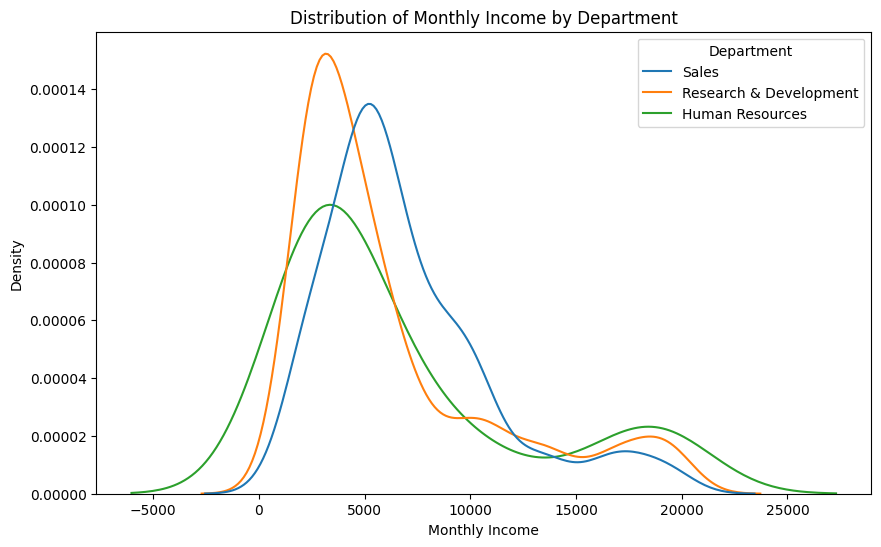

```python
import seaborn as sns
import matplotlib.pyplot as plt
plt.figure(figsize=(10,6))
sns.kdeplot(data=df, x="MonthlyIncome", hue="Department", common_norm=False)
plt.title('Distribution of Monthly Income by Department')
plt.xlabel('Monthly Income')
plt.ylabel('Density')
plt.show()
```

🗣 In the KDE plots of monthly income across departments, we observe two main peaks across all three groups. The first and larger peak likely reflects the salary concentration of regular staff, while the second, smaller peak represents a cluster of higher incomes—possibly associated with senior or leadership roles within each department.

1. The Human Resources department exhibits the widest spread among lower-to-mid income levels. The left side of the distribution is more stretched compared to the other departments, suggesting greater salary variability among junior or administrative HR roles. Notably, the distribution also shows a pronounced density near the 20K income mark. This indicates that HR employees in this company may have better prospects for reaching high salary levels, perhaps due to strategic or specialized HR roles that command premium compensation.
2. The Research & Development department presents a very different pattern: its salary distribution is sharply concentrated around the 2.5K range, with very limited spread. This suggests a standardized salary structure, where most roles fall within a narrow income band, reflecting consistency in role expectations and compensation policies.
3. The Sales department also shares a strong peak around the same income mode (roughly 2.5K to 5K), but its decline after the peak is more gradual than in R&D. This gentler slope toward the right implies the presence of mid-level roles that offer moderate income increases. Moreover, the emergence of a minor density rise around the 10K mark may suggest that certain high-tier sales roles exist in this company—perhaps positions with a fixed base salary near 10K, which is not observed in the other departments.

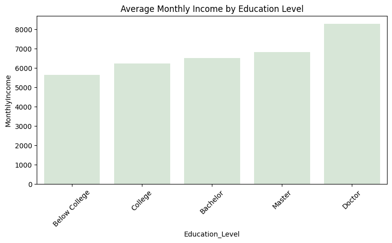

```python
education_map = {
    1: 'Below College',
    2: 'College',
    3: 'Bachelor',
    4: 'Master',
    5: 'Doctor'
}
df['Education_Level'] = df['Education'].map(education_map)
order = ['Below College', 'College', 'Bachelor', 'Master', 'Doctor']

plt.figure(figsize=(8, 5))
sns.barplot(data=df, x='Education_Level', y='MonthlyIncome', order=order, errorbar=None, color='#D5E8D4')
plt.title('Average Monthly Income by Education Level')
plt.xticks(rotation=45)
plt.tight_layout()
plt.show()
```

🗣 The bar plot displays the average monthly income for each level of education. Overall, we observe that higher education levels are associated with higher average salaries.

However, the increase in income between most academic degrees is relatively small, particularly between Bachelor’s and College’s degrees, where the difference is minimal. This suggests that earning a Bachelor’s degree may not lead to a significant salary increase compared to a College’s degree. Although more noticeable jump in salary is observed between those with no college education (Below College) and those with any form of higher education (College and above). Additionally, individuals holding a Doctoral degree experience a substantial increase in income, indicating that this level of education may open access to significantly higher-paying roles.

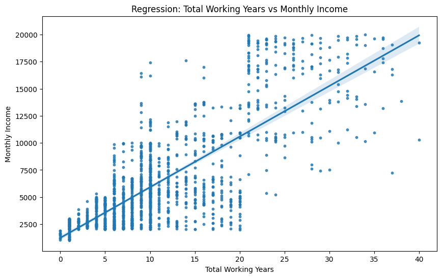

```python
import seaborn as sns
import matplotlib.pyplot as plt
import statsmodels.api as sm

plt.figure(figsize=(10,6))
sns.regplot(x='TotalWorkingYears', y='MonthlyIncome', data=df, scatter_kws={'s': 10})
plt.title('Regression: Total Working Years vs Monthly Income')
plt.xlabel('Total Working Years')
plt.ylabel('Monthly Income')
plt.show()
```

🗣 This regression plot illustrates the relationship between Total Working Years and Monthly Income. It is clearly observed that, on average, monthly income increases with years of experience. The positive slope of the regression line indicates a direct correlation between the two variables. However, as experience increases, income disparity among employees also widens. This is shown by the widening confidence interval (CI) on the right side of the plot. While many experienced employees earn higher salaries, some still receive relatively low income despite having similar levels of experience.

## Task 2: Feature Selection

Mr. Grumbleworth demands proof that you’re using only relevant features. Identify 3 features most correlated with monthly income. Use one feature selection method (e.g., Recursive Feature Elimination, Correlation Thresholding) and justify your choice in a few sentences.

```python
df2 = df.drop("MonthlyIncome", axis=1)
```

```python
#feature selection with
from sklearn.ensemble import RandomForestRegressor
from sklearn.feature_selection import RFE
import pandas as pd
X = pd.get_dummies(df.drop(['MonthlyIncome','EmployeeNumber'],axis=1), drop_first=True)
y = df['MonthlyIncome']
#RandomForest for estimating
rf = RandomForestRegressor(n_estimators=100, random_state=42)
#using RFE for feature selecting
rfe = RFE(estimator=rf, n_features_to_select=10)
rfe.fit(X, y)
selected_cols = X.columns[rfe.support_]
importances = rfe.estimator_.feature_importances_
importance_series = pd.Series(importances, index=selected_cols).sort_values(ascending=False)
print(importance_series)
```

```
JobLevel                     0.926035
TotalWorkingYears            0.012806
JobRole_Research Director    0.012582
DailyRate                    0.009613
MonthlyRate                  0.008516
HourlyRate                   0.008252
JobRole_Manager              0.006216
DistanceFromHome             0.005661
Age                          0.005420
YearsAtCompany               0.004899
dtype: float64
```

```python
from sklearn.linear_model import ElasticNet
from sklearn.preprocessing import StandardScaler
from sklearn.model_selection import train_test_split
from sklearn.metrics import r2_score
X_train, X_test, y_train, y_test = train_test_split(X, y, test_size=0.2, random_state=42)
scaler = StandardScaler()
X_train_scaled = scaler.fit_transform(X_train)
X_test_scaled = scaler.transform(X_test)
model = ElasticNet(alpha=1.0, l1_ratio=0.5, random_state=42)
model.fit(X_train_scaled, y_train)
coef = pd.Series(model.coef_, index=X.columns)
selected_features = coef[coef != 0].sort_values(key=abs, ascending=False)
print("Selected Features by ElasticNet:")
print(selected_features.head(10))
```

```
Selected Features by ElasticNet:
JobLevel                         1549.075945
JobRole_Manager                   957.825542
JobRole_Research Director         853.004066
TotalWorkingYears                 699.782477
JobRole_Research Scientist       -453.659906
JobRole_Laboratory Technician    -419.327969
JobRole_Sales Representative     -256.255170
YearsAtCompany                    231.775450
Age                               218.572331
JobRole_Human Resources          -145.576672
dtype: float64
```

🗣 Among the features evaluated using both ElasticNet and Random Forest-based RFE, three consistently high-impact predictors of monthly income emerged: **JobLevel**, **TotalWorkingYears**, and **JobRole**. JobLevel showed by far the strongest effect in both models. TotalWorkingYears, as a numerical variable, also demonstrated stable and substantial predictive power. Finally, while JobRole is a categorical feature with multiple levels, the repeated selection of several of its categories—combined with their relatively high coefficients and importances—indicates that JobRole as a whole plays a meaningful role in income prediction and is well-justified as the third selected feature.

## Task3: Model Selection & Evaluation

Mr. Grumbleworth demands you test 3 models to ensure the salary predictions are accurate and cost-saving—he’ll tolerate no excuses for overpaying employees. (e.g., Compare Linear Regression, Logistic Regression, Decision Tree, Random Forest, etc... then defend your final choice with hard metrics.)

```python
from sklearn.model_selection import KFold
from sklearn.linear_model import LinearRegression
from sklearn.tree import DecisionTreeRegressor
from sklearn.ensemble import RandomForestRegressor
from sklearn.metrics import mean_squared_error, mean_absolute_error
import pandas as pd
import numpy as np

top_features = ['JobLevel', 'TotalWorkingYears'] + [c for c in X.columns if 'JobRole' in c]
X_selected = X[top_features].values
y_array = y.values

models = {
    'LinearRegression': LinearRegression(),
    'DecisionTree': DecisionTreeRegressor(random_state=42),
    'RandomForest': RandomForestRegressor(n_estimators=100, random_state=42)
}

kf = KFold(n_splits=5, shuffle=True, random_state=42)
results = {}

for name, model in models.items():
    over_mse_scores = []
    over_mae_scores = []

    for train_idx, test_idx in kf.split(X_selected):
        X_train, X_test = X_selected[train_idx], X_selected[test_idx]
        y_train, y_test = y_array[train_idx], y_array[test_idx]

        model.fit(X_train, y_train)
        preds = model.predict(X_test)

        over_mask = preds > y_test
        if over_mask.any():
            y_over = y_test[over_mask]
            preds_over = preds[over_mask]

            mse = mean_squared_error(y_over, preds_over)
            mae = mean_absolute_error(y_over, preds_over)

            over_mse_scores.append(mse)
            over_mae_scores.append(mae)

    results[name] = {
        'MSE_over': np.mean(over_mse_scores),
        'MAE_over': np.mean(over_mae_scores)
    }

results_df = pd.DataFrame(results).T.sort_values('MSE_over')
print(results_df)
```

```
                      MSE_over    MAE_over
RandomForest      9.679172e+05  763.574219
DecisionTree      1.022149e+06  779.412634
LinearRegression  1.209257e+06  851.039318
```

🗣 We trained three models—Linear Regression, Decision Tree, and Random Forest—using key features such as job level and total working years. Evaluation was performed using 5-fold cross-validation, with a specific focus on cases where the model over-predicted salaries. We then calculated the average MSE and MAE on these over-predicted instances to identify the most cost-efficient model for minimizing overpayment.

Random Forest achieved the lowest overprediction error (both MAE and MSE on overpaid cases), making it the most reliable model for minimizing unnecessary salary costs. We therefore select it as the final model.

## Task 4: Explainability

Mr. Grumbleworth wants to cut costs by manipulating key factors. Use feature importance (e.g., Linear Regression’s Coefficients, Decision Tree's Feature Importance) and list the top 3 features driving monthly salary. Suggest one action to reduce salaries (e.g., "Limit promotions (JobLevel).").

```python
# Write your answer here:
print(importance_series.head(3))
```

```
JobLevel                     0.926035
TotalWorkingYears            0.012806
JobRole_Research Director    0.012582
dtype: float64
```

🗣 Since Random Forest had already been trained for feature selection in Task 2 and proved to be the most cost-efficient model in Task 3, we proceeded to use it for analyzing feature importance via its feature_importances_.

The top feature was JobLevel with a high importance score of 0.926, indicating that higher job levels significantly increase salary. To control costs, we recommend limiting promotions to higher job levels through stricter criteria or capping the number of senior roles.

The second most important feature was TotalWorkingYears (importance: 0.0128), suggesting that more experience correlates with higher pay. A revised compensation structure based on performance rather than tenure is advisable.

The third feature, JobRole_Research Director (importance: 0.0126), shows that this role commands higher salaries. Limiting hiring in senior research positions, or filling them with capable professionals at lower levels, could help reduce salary costs while meeting business needs.

## Task 5: Education Impact

Mr. Grumbleworth thinks higher education might not always mean higher salary.

1. Check how salary changes with education level.
2. Group the data by education and show the average salary for each level in a chart.

Then:

1. Train a machine learning model (e.g., Random Forest).
2. Use a method like Partial Dependence Plot or SHAP to check how changes in education level affect the predicted salary in your model.

```python
# Write your answer here:
import pandas as pd
education_map = {
    1: 'Below College',
    2: 'College',
    3: 'Bachelor',
    4: 'Master',
    5: 'Doctor'
}
df['Education_Level'] = df['Education'].map(education_map)
avg_income_by_education = df.groupby('Education_Level')['MonthlyIncome'].mean().sort_values()
print(avg_income_by_education)
```

```
Education_Level
Below College    5640.570588
College          6226.645390
Bachelor         6517.263986
Master           6832.402010
Doctor           8277.645833
Name: MonthlyIncome, dtype: float64
```

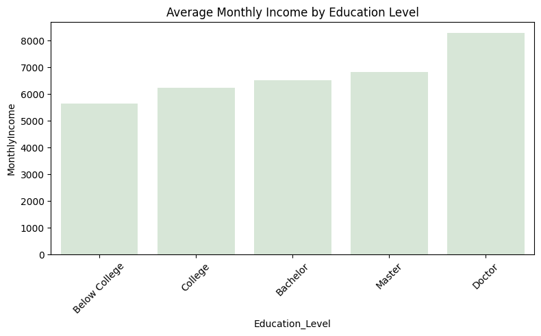

```python
order = ['Below College', 'College', 'Bachelor', 'Master', 'Doctor']
plt.figure(figsize=(8, 5))
sns.barplot(data=df, x='Education_Level', y='MonthlyIncome', order=order, errorbar=None, color='#D5E8D4')
plt.title('Average Monthly Income by Education Level')
plt.xticks(rotation=45)
plt.tight_layout()
plt.show()
```

🗣 We trained a Random Forest model to predict monthly income, using 80% of the data for training and 20% for testing. SHAP values were then used to analyze how each education level influenced the model’s salary predictions.

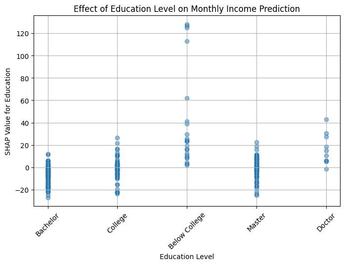

```python
import shap
X_selected = pd.get_dummies(df.drop(["MonthlyIncome","Education_Level"], axis=1), drop_first=True)
y = df["MonthlyIncome"]
X_train, X_test, y_train, y_test = train_test_split(X_selected, y, test_size=0.2, random_state=42)
model = RandomForestRegressor(n_estimators=100, random_state=42)
model.fit(X_train, y_train)
explainer = shap.TreeExplainer(model)
shap_values = explainer.shap_values(X_test)
edu_index = X_test.columns.get_loc("Education")
education_shap = shap_values[:, edu_index]
edu_mapped = X_test["Education"].map(education_map)
plt.figure(figsize=(8, 5))
plt.scatter(edu_mapped, education_shap, alpha=0.5)
plt.xlabel("Education Level")
plt.ylabel("SHAP Value for Education")
plt.title("Effect of Education Level on Monthly Income Prediction")
plt.grid(True)
plt.xticks(rotation=45)
plt.show()
```

🗣 The "Below College" group shows the strongest impact on salary predictions, with notably higher SHAP values. This suggests that individuals without a college degree have distinct income patterns, leading the model to adjust their predicted salaries more significantly.

## Task 6: Analyzing How Experience in a Profession and Years at the Company Affect Payments in Different Departments

Mr. Grumbleworth, always seeking efficiency, demands to understand how employees’ experience in their profession and their time at the company impact salary increases across different departments. “I need to know which departments are rewarding long-term commitment and expertise,” he says. “Group the employees by department and figure out how these two factors—experience in the field and years with the company—are affecting their pay. Let’s see where we’re investing the most in growth and loyalty.

1. Calculate the Impact of Experience and Time at the Company on Salary: For each department, assess how the years of experience in the profession and the number of years at the company impact salary (e.g., using linear regression).

   Hint: For each department, run a linear regression with salary as the dependent variable, and years of experience and years at the company as independent variables. Use the regression coefficients (e.g., Salary = B₀ + B₁ × Experience + B₂ × TimeAtCompany). Then, create a combined impact metric for each department using B₁ + B₂ to represent the total rate of salary growth per year of combined experience and tenure.
2. Rank Departments Based on Salary Influence: Rank the departments based on how strongly experience in the profession and time at the company influence salary increases, and analyze which departments are most affected by these factors.

```python
import pandas as pd
import statsmodels.api as sm

for dept, group in df.groupby('Department'):
    X = group[['TotalWorkingYears', 'YearsAtCompany']]
    y = group['MonthlyIncome']
    X = sm.add_constant(X)
    model = sm.OLS(y, X).fit()
    params = model.params
    b1 = params.get('TotalWorkingYears', 0)
    b2 = params.get('YearsAtCompany', 0)
    combined = b1 + b2
    print(f"\n====== Department: {dept} ======")
    print(params)
    print(f"\nCombined Score: {combined}")
```

```
====== Department: Human Resources ======
const                -39.046616
TotalWorkingYears    580.146057
YearsAtCompany        -1.430685
dtype: float64

Combined Score: 578.7153714564231

====== Department: Research & Development ======
const                775.392921
TotalWorkingYears    468.092124
YearsAtCompany        28.638358
dtype: float64

Combined Score: 496.7304824111068

====== Department: Sales ======
const                2258.943702
TotalWorkingYears     386.377139
YearsAtCompany         56.194564
dtype: float64

Combined Score: 442.5717033626876
```

🗣 Based on the combined impact of experience and company tenure (i.e., the sum of the coefficients β₁ + β₂), the Human Resources department shows the highest overall influence on salary growth. At first glance, this suggests that HR rewards experience and loyalty more than any other department.

However, when we examine the individual coefficients more closely, a more nuanced picture emerges: